# Lesson 5

Timothy Luna

8/20/2019

# Filters as Templates

## Intro

Previously in the course we’ve discussed correlation vs convolution and how they are different with respect to output orientation.

Now think of filters as getting at an intermediary representation of an image. Special filters can find strong responses to questions you are interested in.

Convert the pixels to a new array, but now the function output of the filter isn’t about the initensity, rather it’s about a local property of the image. Perhaps you are interested in the local average, the local median, or whether a certain amount of pixels in a filter cross a threshold.

One caveat: Previously we discussed linear operators. Comparing two linear outputs of two different filters is straightforward but when comparing two filters it’s important that the multiplicative factor of the filter scales are the same.

Assumptions and necessary considerations made when we do correlation:

1. Normalize filters by making the $\sigma$ of all filters equal to 1.
2. When we apply the filter to a patch of pixels we scale the patch to normalize it to a $\sigma$ of 1.

Normalizing the filter is necessary to compare filters!

## 1D Correlation

Given a one dimensional signal wth a filter equal to a very small subsection of the 1d filter; when the normalized correlation filter is applied to the signal it produces an output that is at its maximum when it is at the point where the filter matches the image where it was cut from.

The correlated output will be at its highest when filter and image match with the coefficient signs and the signal matches the filter.

## OpenCV Cross Correlation Documentation and Template Matching

Let’s explore using filters as templates of what we want to find in two dimensions.

Given a two-dimensional image take a small chunk of an image and after normalizing use that as a filter.

```python
# https://docs.opencv.org/master/df/dfb/group__imgproc__object.html#ga3a7850640f1fe1f58fe91a2d7583695d
import cv2

img = cv.imread('tablet.png')
img2 = np.copy(img)
# What do we want the template filter to be?
template = img[99:160,224:270,:]
h, w, _ = template.shape

# Which methods would we like to test? This is an enumerated list.
methods = ['cv.TM_SQDIFF',
           'cv.TM_SQDIFF_NORMED',
           'cv.TM_CCORR',
           'cv.TM_CCORR_NORMED',
           'cv.TM_CCOEFF',
           'cv.TM_CCOEFF_NORMED']

# What effect do the different methods have?
for method, name in enumerate(methods):
  img3 = np.copy(img2)
  res = cv2.matchTemplate(img,template,method)
  # Where in the image does the template match best?
  min_val, max_val, min_loc, max_loc = cv2.minMaxLoc(res)
  if name in ['cv.TM_SQDIFF','cv.TM_SQDIFF_NORMED']:
    # Use the minimum
    top_left = min_loc
  else:
    # Otherwise use the maximum
    top_left = max_loc
  bottom_right = (top_left[0] + w, top_left[1] + h)
  cv2.rectangle(img3,top_left, bottom_right, 255, 2)
  plt.subplot(121),plt.imshow(res,cmap = 'gray')
  plt.title('Matching Result'), plt.xticks([]), plt.yticks([])
  plt.subplot(122),plt.imshow(img3,cmap = 'gray')
  plt.title('Detected Point'), plt.xticks([]), plt.yticks([])
  plt.suptitle(name)
  plt.show()
```

### TM_SQDIFF

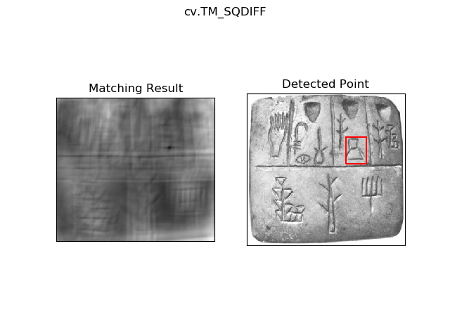

### TM_CCORR_NORMED

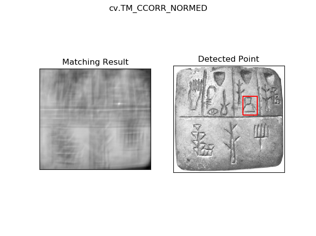

### TM_SQDIFF_NORMED

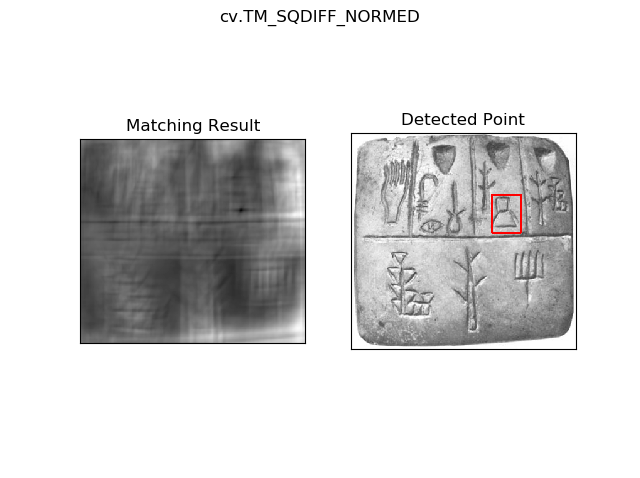

### TM_CCOEFF

[figure not shown]

### TM_CCORR

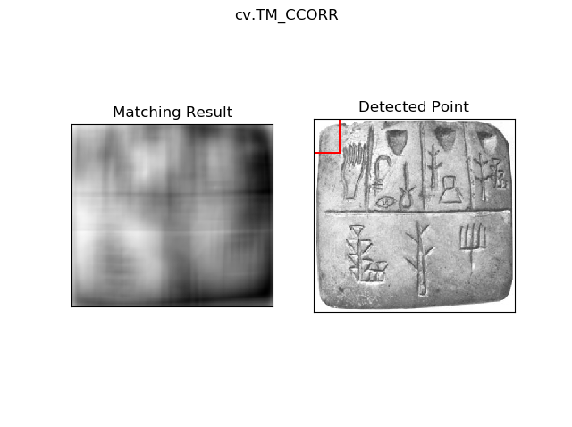

### TM_CCOEFF_NORMED

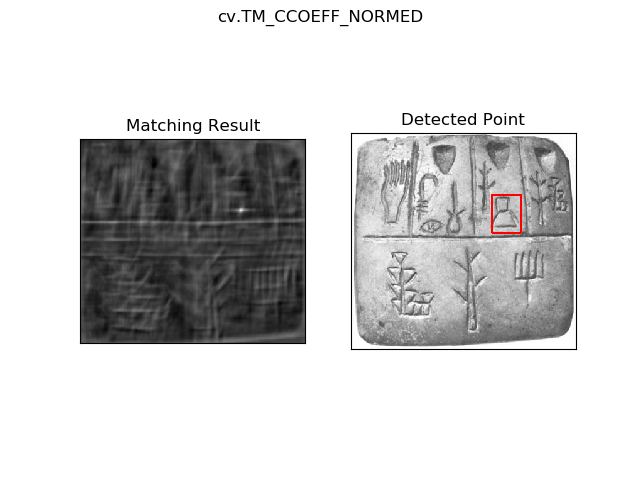

Note that almost all the methods performed fairly well on the toy image; only CCORR resulted in poor results.

## Where’s Waldo

How can we solve Where’s Waldo with template matching? We have a picture of Waldo as a template and we filter the original image with that kernel then assume the highest (or lowest, depending on the math) value is Waldo’s location.

## Quiz: What is it good for?

You can find anything that’s reasonably static with templates. Faces are difficult but possible, but computer icons are easy. The noisier the image the less likely template matching will produce *exactly* what you want.

## Non Identical Template Matching

What if the template isn’t identiacl? Say a car matching a truck. It’s quite possible that you might still get a good match! Cars are all relatively the same… boxy things on wheels. The shapes might be a little different but they both have windows in around the same places, wheels in around the same places, etc…

## Quiz: Normalized Correlation

This method would not work well for finding Waldo in most pictures; there’s too much noise! We would need the exact template (picture of Waldo) every time. If we had a general template we’d get tons of false positives (also called *candidate* examples.)